# ADOPTION REVENUE DYNAMICS AND GRANT CONTRIBUTIONS IN ANIMAL WELFARE PROGRAMS

```python
import pandas as pd
```

```python
df=pd.read_csv(r"Animal_Care_and_Control_Division_Annual_Statistics.csv")
```

## Trend Analysis: How have total animal intake and euthanasia rates changed annually from 2004 to 2023, and what factors correlate with these trends?

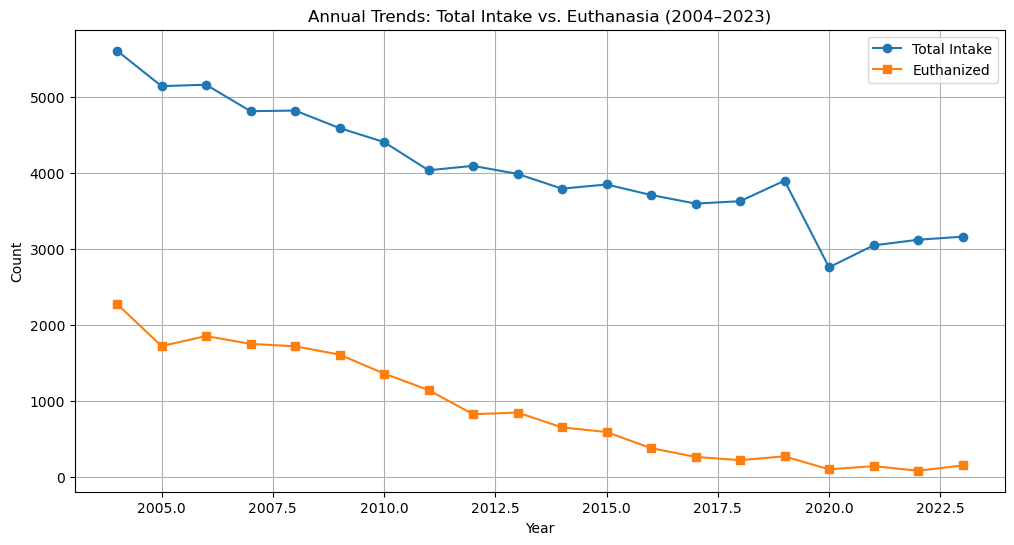

```python
import pandas as pd
import matplotlib.pyplot as plt

df = pd.read_csv('Animal_Care_and_Control_Division_Annual_Statistics.csv')

# Line chart
plt.figure(figsize=(12, 6))
plt.plot(df['Year'], df['Total Intake of Animals'], marker='o', label='Total Intake')
plt.plot(df['Year'], df['Euthanized'], marker='s', label='Euthanized')
plt.title('Annual Trends: Total Intake vs. Euthanasia (2004–2023)')
plt.xlabel('Year')
plt.ylabel('Count')
plt.grid(True)
plt.legend()
plt.savefig("'Annual Trends: Total Intake vs. Euthanasia (2004–2023).png")
plt.show()
```

## Policy Impact: Did the introduction of "Impounds by ACO" in 2015 significantly alter the distribution of intake sources (strays, surrenders, impounds) or euthanasia rates?

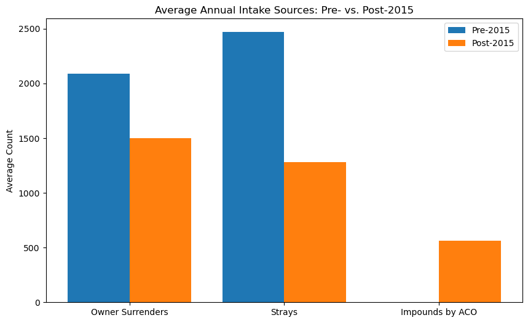

```python
# Grouped bar chart (pre- vs. post-2015)
df_pre = df[df['Year'] < 2015]
df_post = df[df['Year'] >= 2015]

# Use the correct column name from the dataset
intake_sources = ['Owner Surrenders', 'Strays', 'Impounds by ACO (Added in 2015)']
pre_avg = df_pre[['Owner Surrenders', 'Strays']].mean().tolist() + [0]  # 0 for missing pre-2015 data
post_avg = df_post[intake_sources].mean().tolist()  # Now includes the correct column

# Visualization
plt.figure(figsize=(10, 6))
plt.bar([x-0.2 for x in range(3)], pre_avg, width=0.4, label='Pre-2015')
plt.bar([x+0.2 for x in range(3)], post_avg, width=0.4, label='Post-2015')
plt.xticks(range(3), ['Owner Surrenders', 'Strays', 'Impounds by ACO'])  # Simplified labels
plt.title('Average Annual Intake Sources: Pre- vs. Post-2015')
plt.ylabel('Average Count')
plt.legend()
plt.savefig("Average Annual Intake Sources: Pre- vs. Post-2015.png")
plt.show()
```

## Budget Efficiency: Is there a statistically significant relationship between annual budget increases and improvements in key outcomes like adoptions, returns to owners, or reductions in euthanasia?

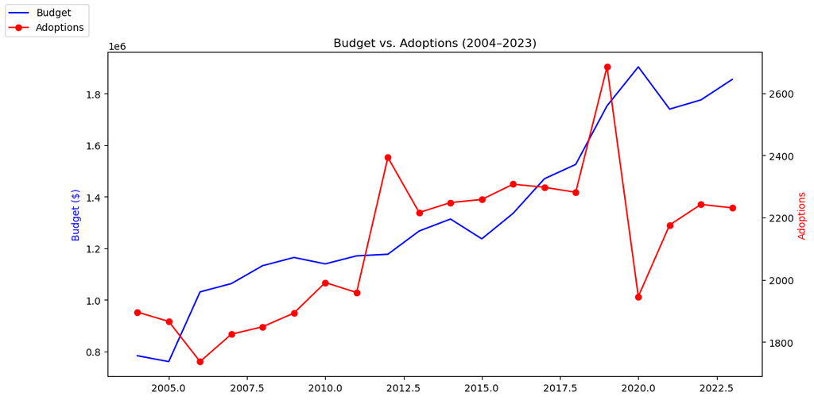

```python
# Dual-axis line chart
fig, ax1 = plt.subplots(figsize=(12, 6))
ax1.plot(df['Year'], df['Annual Budget'], color='blue', label='Budget')
ax1.set_ylabel('Budget ($)', color='blue')
ax2 = ax1.twinx()
ax2.plot(df['Year'], df['Adoptions'], color='red', marker='o', label='Adoptions')
ax2.set_ylabel('Adoptions', color='red')
plt.title('Budget vs. Adoptions (2004–2023)')
fig.legend(loc='upper left')
plt.savefig("Budget vs. Adoptions (2004–2023).png")
plt.show()
```

## Funding Streams: How do grants and adoption revenue contribute to operational sustainability, and what trends exist in these funding sources over time?

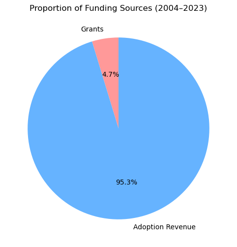

```python
# Pie chart
grants_total = df['Grants Received'].sum()
adoption_revenue_total = df['Annual Adoption Revenue'].sum()
labels = ['Grants', 'Adoption Revenue']
sizes = [grants_total, adoption_revenue_total]

plt.figure(figsize=(8, 6))
plt.pie(sizes, labels=labels, autopct='%1.1f%%', startangle=90, colors=['#ff9999','#66b3ff'])
plt.title('Proportion of Funding Sources (2004–2023)')
plt.savefig("Proportion of Funding Sources (2004–2023).png")
plt.show()
```

## Staffing Dynamics: Does the number of employees correlate with service call responsiveness, emergency call-outs, or intake processing efficiency?

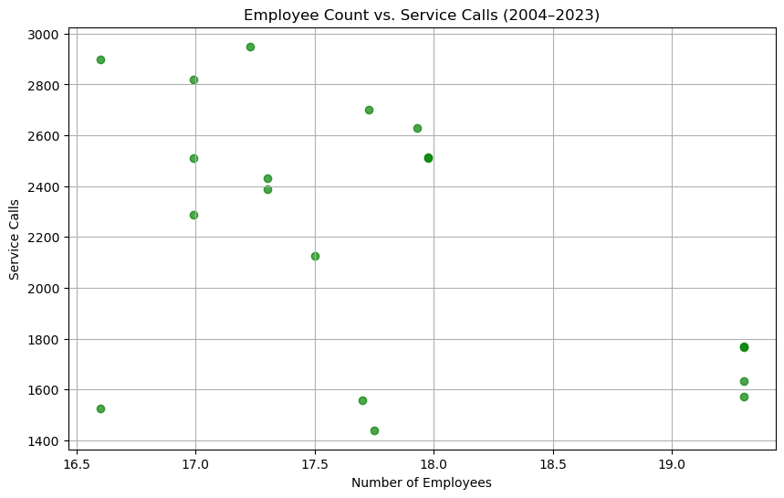

```python
# Scatter plot
plt.figure(figsize=(10, 6))
plt.scatter(df['Number of Employees'], df['Service Calls'], c='green', alpha=0.7)
plt.title('Employee Count vs. Service Calls (2004–2023)')
plt.xlabel('Number of Employees')
plt.ylabel('Service Calls')
plt.grid(True)
plt.savefig("Employee Count vs. Service Calls.png")
plt.show()
```

## Foster Program Impact: How has the growth in fostered animals influenced live release rates (adoptions + returns + transports + fosters) since 2005?

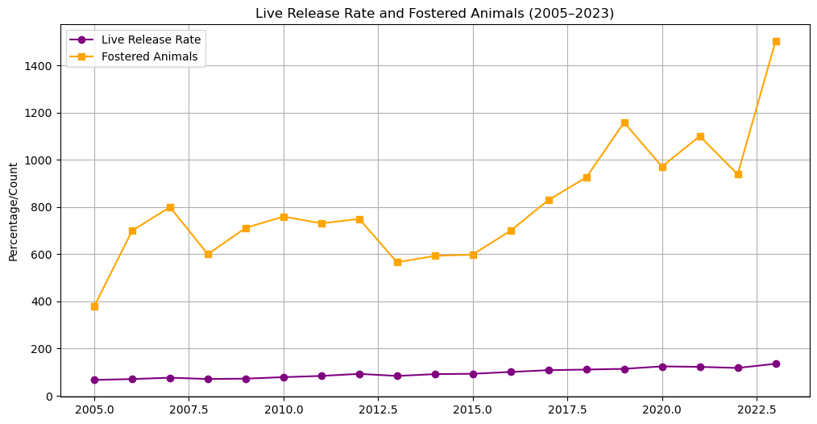

```python
# Calculate live release rate
df['Live Release'] = df['Adoptions'] + df['Return to Owner'] + df['Transported to other shelters and rescues'] + df['Fostered Animals']
df['Live Release Rate'] = (df['Live Release'] / df['Total Intake of Animals']) * 100

# Line chart
plt.figure(figsize=(12, 6))
plt.plot(df['Year'], df['Live Release Rate'], marker='o', color='purple', label='Live Release Rate')
plt.plot(df['Year'], df['Fostered Animals'], marker='s', color='orange', label='Fostered Animals')
plt.title('Live Release Rate and Fostered Animals (2005–2023)')
plt.ylabel('Percentage/Count')
plt.legend()
plt.grid(True)
plt.savefig("Live Release Rate and Fostered Animals.png")
plt.show()
```

## Crisis Response: What explains the sharp decline in total intake (e.g., 2020) and euthanasia rates post-2016? Could external events (e.g., pandemics, policy shifts) explain these anomalies?

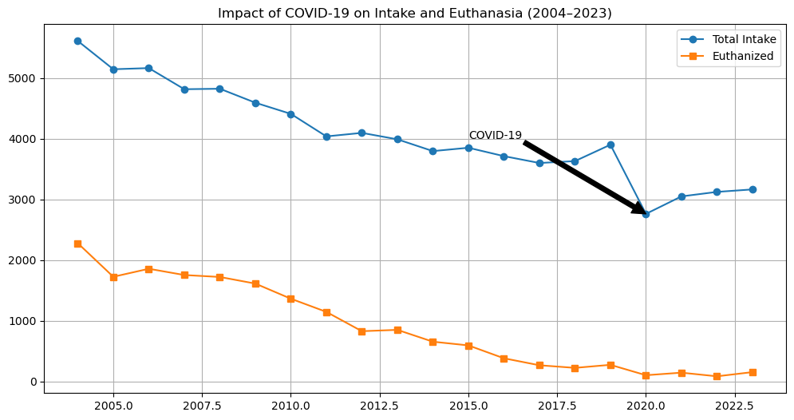

```python
# Highlight 2020
plt.figure(figsize=(12, 6))
plt.plot(df['Year'], df['Total Intake of Animals'], marker='o', label='Total Intake')
plt.plot(df['Year'], df['Euthanized'], marker='s', label='Euthanized')
plt.annotate('COVID-19', xy=(2020, 2760), xytext=(2015, 4000), arrowprops=dict(facecolor='black'))
plt.title('Impact of COVID-19 on Intake and Euthanasia (2004–2023)')
plt.legend()
plt.grid(True)
plt.savefig("Impact of COVID-19 on Intake and Euthanasia.png")
plt.show()
```

## Operational Costs: What is the cost per animal intake (annual budget ÷ total intake), and how has this metric evolved alongside changes in adoption revenue?

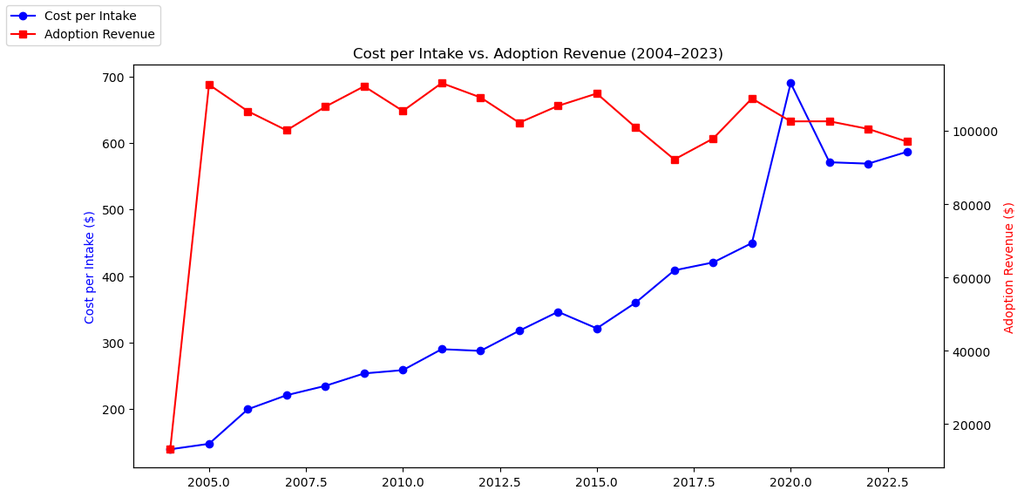

```python
# Calculate cost per intake
df['Cost per Intake'] = df['Annual Budget'] / df['Total Intake of Animals']

# Dual-axis line chart
fig, ax1 = plt.subplots(figsize=(12, 6))
ax1.plot(df['Year'], df['Cost per Intake'], color='blue', marker='o', label='Cost per Intake')
ax1.set_ylabel('Cost per Intake ($)', color='blue')
ax2 = ax1.twinx()
ax2.plot(df['Year'], df['Annual Adoption Revenue'], color='red', marker='s', label='Adoption Revenue')
ax2.set_ylabel('Adoption Revenue ($)', color='red')
plt.title('Cost per Intake vs. Adoption Revenue (2004–2023)')
fig.legend(loc='upper left')
plt.savefig("Cost per Intake vs. Adoption Revenue.png")
plt.show()
```

## Vehicle Utilization: With only 3–4 division vehicles, how does fleet size correlate with impound rates, service calls, or geographic coverage over time?

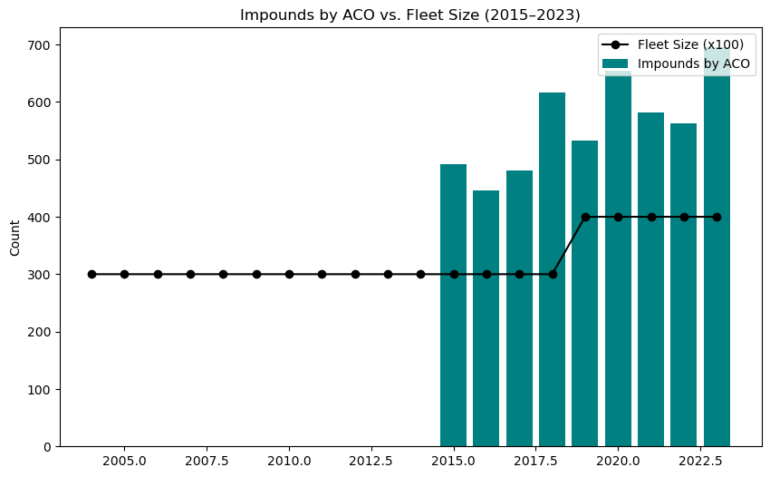

```python
# Bar chart for impounds vs. fleet size
plt.figure(figsize=(10, 6))

# Use the FULL column name from the dataset
plt.bar(df['Year'], df['Impounds by ACO (Added in 2015)'], color='teal', label='Impounds by ACO')
plt.plot(df['Year'], df['Number of Division Vehicles']*100, color='black', marker='o', label='Fleet Size (x100)')

plt.title('Impounds by ACO vs. Fleet Size (2015–2023)')
plt.ylabel('Count')
plt.legend()
plt.savefig("Impounds by ACO vs. Fleet Size.png")
plt.show()
```

## Owner Surrender Drivers: Are there correlations between economic indicators (e.g., budget cuts/recessions) and spikes in owner surrenders (e.g., 2009 vs. 2020)?

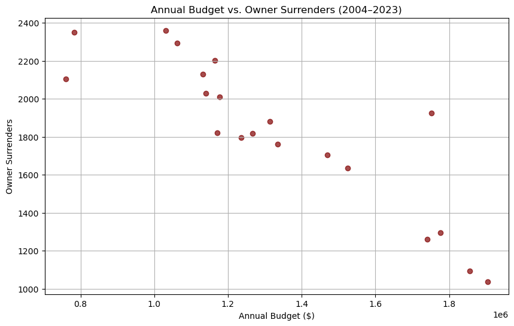

```python
# Scatter plot: Budget vs. Owner Surrenders
plt.figure(figsize=(10, 6))
plt.scatter(df['Annual Budget'], df['Owner Surrenders'], c='maroon', alpha=0.7)
plt.title('Annual Budget vs. Owner Surrenders (2004–2023)')
plt.xlabel('Annual Budget ($)')
plt.ylabel('Owner Surrenders')
plt.grid(True)
plt.savefig("Annual Budget vs. Owner Surrenders.png")
plt.show()
```

## Return-to-Owner Success: What variables (e.g., service calls, budget allocation) most strongly predict successful returns of animals to owners?

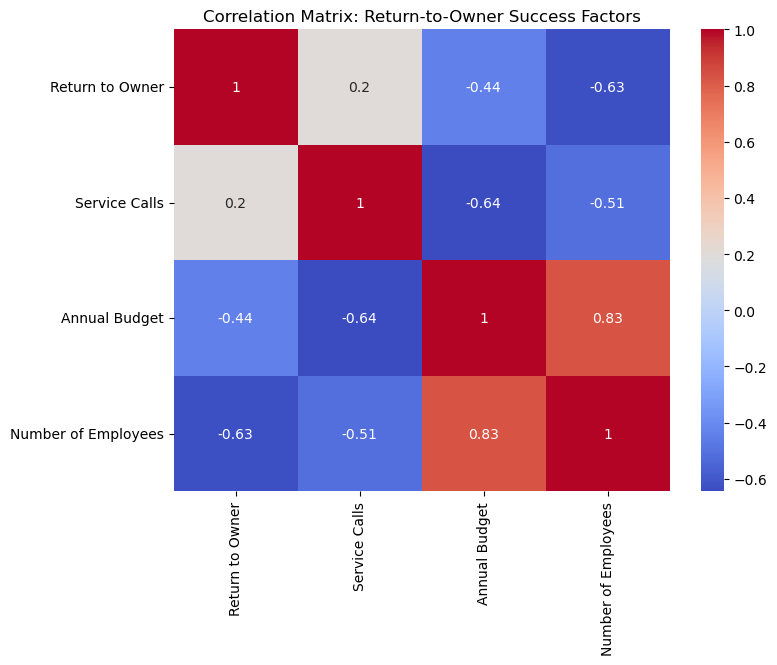

```python
# Heatmap of correlations
import seaborn as sns

corr_matrix = df[['Return to Owner', 'Service Calls', 'Annual Budget', 'Number of Employees']].corr()
plt.figure(figsize=(8, 6))
sns.heatmap(corr_matrix, annot=True, cmap='coolwarm')
plt.title('Correlation Matrix: Return-to-Owner Success Factors')
plt.savefig("Correlation Matrix: Return-to-Owner Success Factors.png")
plt.show()
```

## Emergency Workload: Do emergency call-outs disproportionately strain resources, and how do they correlate with seasonal intake fluctuations or staffing levels?

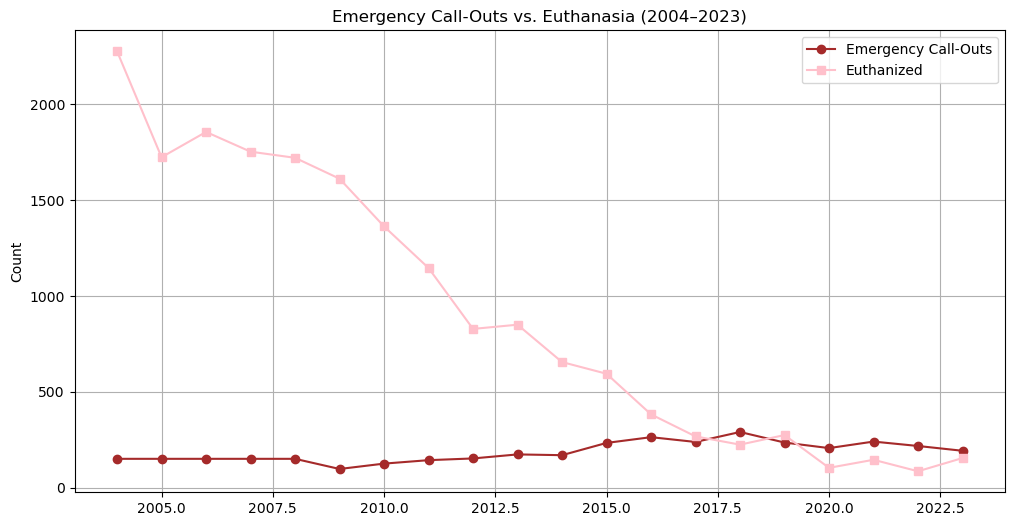

```python
# Line chart
plt.figure(figsize=(12, 6))
plt.plot(df['Year'], df['Emergency Call-Outs'], marker='o', color='brown', label='Emergency Call-Outs')
plt.plot(df['Year'], df['Euthanized'], marker='s', color='pink', label='Euthanized')
plt.title('Emergency Call-Outs vs. Euthanasia (2004–2023)')
plt.ylabel('Count')
plt.legend()
plt.grid(True)
plt.savefig("Emergency Call-Outs vs. Euthanasia.png")
plt.show()
```

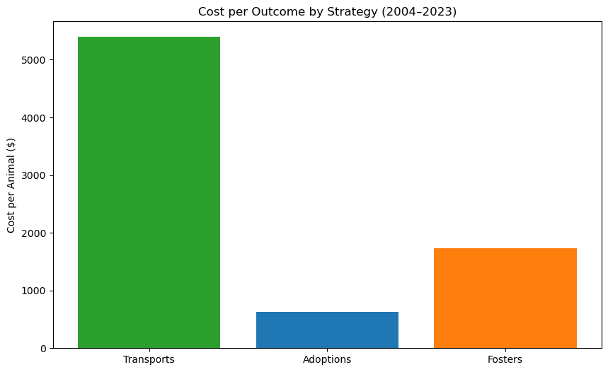

```python
# Calculate cost per outcome
cost_transport = df['Annual Budget'].sum() / df['Transported to other shelters and rescues'].sum()
cost_adoption = df['Annual Budget'].sum() / df['Adoptions'].sum()
cost_foster = df['Annual Budget'].sum() / df['Fostered Animals'].sum()

# Bar chart
strategies = ['Transports', 'Adoptions', 'Fosters']
costs = [cost_transport, cost_adoption, cost_foster]

plt.figure(figsize=(10, 6))
plt.bar(strategies, costs, color=['#2ca02c', '#1f77b4', '#ff7f0e'])
plt.title('Cost per Outcome by Strategy (2004–2023)')
plt.ylabel('Cost per Animal ($)')
plt.savefig("Cost per Outcome by Strategy.png")
plt.show()
```

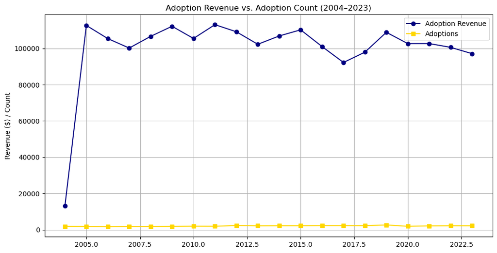

```python
# Line chart
plt.figure(figsize=(12, 6))
plt.plot(df['Year'], df['Annual Adoption Revenue'], marker='o', color='navy', label='Adoption Revenue')
plt.plot(df['Year'], df['Adoptions'], marker='s', color='gold', label='Adoptions')
plt.title('Adoption Revenue vs. Adoption Count (2004–2023)')
plt.ylabel('Revenue ($) / Count')
plt.legend()
plt.grid(True)
plt.savefig("Adoption Revenue vs. Adoption Count.png")
plt.show()
```

## Long-Term Outcomes: How have cumulative improvements (e.g., reduced euthanasia, increased adoptions) aligned with broader animal welfare goals, and what gaps remain?

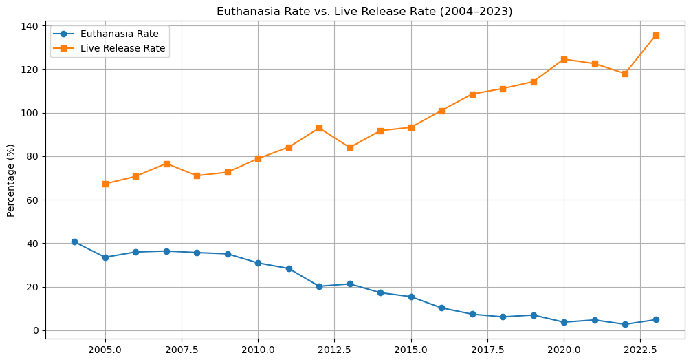

```python
# Combined line chart
plt.figure(figsize=(12, 6))
plt.plot(df['Year'], df['Euthanized'] / df['Total Intake of Animals'] * 100, marker='o', label='Euthanasia Rate')
plt.plot(df['Year'], df['Live Release Rate'], marker='s', label='Live Release Rate')
plt.title('Euthanasia Rate vs. Live Release Rate (2004–2023)')
plt.ylabel('Percentage (%)')
plt.legend()
plt.grid(True)
plt.savefig("Euthanasia Rate vs. Live Release Rate.png")
plt.show()
```